# Библиотека NumPy

Сферы использования NumPy:

1. Научные вычисления (решение многомерных задач в математике, физике, вычислительной химии, биоинформатике и т.д.)
2. Data Science. В основе экосистемы для анализа данных лежит NumPy. Ее используют для извлечения и преобразования данных, анализа, моделирования и оценки.
3. Machine Learning. Библиотеки для машинного обучения scikit-learn и SciPy тоже работают благодаря вычислительным возможностям NumPy
4. Визуализация данных.

# Почему мы используем numpy

NumPy (Numeric Python) - это библиотека Python с открытым исходным кодом, которая используется практически во всех областях науки и техники.

Это универсальный стандарт для работы с числовыми данными в Python, и он лежит в основе научных экосистем Python и PyData.

В число пользователей NumPy входят все - от начинающих программистов до опытных исследователей, занимающихся самыми современными научными и промышленными исследованиями и разработками.

NumPy API широко используется в пакетах Pandas, SciPy, Matplotlib, scikit-learn, scikit-image и в большинстве других научных и научных пакетов Python.

Библиотека NumPy содержит многомерный массив и матричные структуры данных. Она предоставляет ndarray, однородный объект n-мерного массива, с методами для эффективной работы с ним.

NumPy может использоваться для выполнения множества математических операций над массивами.

Он добавляет мощные структуры данных в Python, которые гарантируют эффективные вычисления с массивами и матрицами, и предоставляет огромную библиотеку математических функций высокого уровня, которые работают с этими массивами и матрицами.

```python
# установим библиотеку
!pip install numpy
```

```python
# импортируем библиотеку
import numpy as np
```

```python
# посмотреть версию библиотеки
np.__version__
```

```
'1.24.3'
```

### Одномерные и многомерные массивы

Главный объект numpy - array. Массивы схожи со списками в python, но элементы массива должны иметь одинаковый тип данных (float и int). С массивами можно проводить числовые операции с большим объемом информации в разы быстрее и, главное, намного эффективнее чем со списками.

Массивы NumPy быстрее и компактнее, чем списки Python. Массив потребляет меньше памяти и удобны в использовании. NumPy использует гораздо меньше памяти для хранения данных и предоставляет механизм указания типов данных. Это позволяет оптимизировать код еще лучше.

```python
a = np.array([1, 2, 3])
print(a, '|', type(a))
```

```
[1 2 3] | <class 'numpy.ndarray'>
```

```python
a.dtype
```

```
dtype('int32')
```

Массив является центральной структурой данных библиотеки NumPy. Массив - это сетка значений, которая содержит информацию о необработанных данных, о том, как найти элемент и как интерпретировать элемент. Он имеет сетку элементов, которые могут быть проиндексированы различными способами. Все элементы имеют одинаковый тип, называемый массивом dtype. Массив может быть проиндексирован набором неотрицательных целых чисел, логическими значениями, другим массивом или целыми числами. Ранг массива - это число измерений. Форма массива представляет собой набор целых чисел, дающих размер массива по каждому измерению.

```python
a = np.array([[1, 2, 3], [4, 5, 6]], float)
print(a, '|', type(a))
```

```
[[1. 2. 3.]
 [4. 5. 6.]] | <class 'numpy.ndarray'>
```

Мы можем получить доступ к элементам в массиве, используя квадратные скобки. Когда вы обращаетесь к элементам, помните, что индексирование в NumPy начинается с 0. Это означает, что если вы хотите получить доступ к первому элементу в вашем массиве, вы получите доступ к элементу «0».

```python
a[0]
```

```
array([1., 2., 3.])
```

В двумерном массиве сначала указывем номер строки, потом номер столбца.

Нумерация строк и столбцов начинается с нуля.

Доступ к элементу во 2 строке, 3 столбце

```python
a[1,2]
```

```
6.0
```

Иногда вы можете услышать термин массив, называемый «ndarray», который является сокращением от «N-мерный массив». N-мерный массив - это просто массив с любым количеством измерений. Вы также можете сказать 1-D, или одномерный массив, 2-D, или двумерный массив, и так далее.

Класс NumPy ndarray используется для представления как матриц, так и векторов. Вектор - это массив с одним измерением (нет разницы между векторами строки и столбца), а матрица ссылается на массив с двумя измерениями.

Для трехмерных или более крупных размерных массивов также обычно используется термин тензор.

## Инициализация массива

Все, что вам нужно сделать, чтобы создать простой массив, это передать ему список. При желании вы также можете указать тип данных в вашем списке. Вы можете найти больше информации о типах данных [здесь](https://numpy.org/devdocs/reference/arrays.dtypes.html#arrays-dtypes).

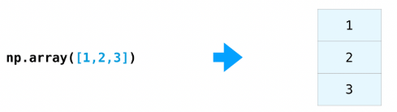

Помимо создания массива из последовательности элементов, вы можете легко создать массив, заполненный нулями:

```python
np.zeros(10)
```

```
array([0., 0., 0., 0., 0., 0., 0., 0., 0., 0.])
```

```python
np.zeros((3, 2))
```

```
array([[0., 0.],
       [0., 0.],
       [0., 0.]])
```

Или массив, заполненный 1:

```python
np.ones(8)
```

```
array([1., 1., 1., 1., 1., 1., 1., 1.])
```

```python
np.ones((2, 3))
```

```
array([[1., 1., 1.],
       [1., 1., 1.]])
```

Или даже пустой массив! Функция empty создает массив, исходное содержимое которого является случайным и зависит от состояния памяти. Причиной использования пустых над нулями (или чего-то подобного) является скорость - просто убедитесь, что все элементы заполнены впоследствии!

```python
np.empty(4)
```

```
array([1.06099790e-313, 1.65515672e-312, 1.06099790e-313, 6.36598737e-314])
```

Вы можете создать массив с диапазоном элементов:

```python
np.arange(4)
```

```
array([0, 1, 2, 3])
```

И даже массив, который содержит диапазон равномерно распределенных интервалов. Для этого вам необходимо указать первое число, последнее число и размер шага.

Правая граница не будет включена.

```python
np.arange(2, 9, 2)
```

```
array([2, 4, 6, 8])
```

Вы также можете использовать np.linspace () для создания массива со значениями, которые расположены линейно с заданным интервалом.

Правая граница будет включена. Шаг будет вычислен авторматически.

```python
# от 0 до 10, 5 чисел с равным шагом
np.linspace(0, 10, 5)
```

```
array([ 0. ,  2.5,  5. ,  7.5, 10. ])
```

Cоздать массив указанной размерности, заполненный указанным значением.

Размерность задается в виде кортежа.

```python
np.full((2, 3), 10)
```

```
array([[10, 10, 10],
       [10, 10, 10]])
```

Создать единичую матрицу.

```python
np.eye(4)
```

```
array([[1., 0., 0., 0.],
       [0., 1., 0., 0.],
       [0., 0., 1., 0.],
       [0., 0., 0., 1.]])
```

детальнее о [процедурах](https://numpy.org/devdocs/reference/routines.array-creation.html#routines-array-creation) создания массивов

## Поэлементные действия над массивами

Если мы хотим применить одно и то же действие ко всем элементам массива, достаточно применить его к массиву в целом. Например, для умножения всех элементов массива на 2, нужно умножить на 2 сам массив.

```python
c = np.array([1, 2, 3, 4, 5, 6, 7, 8])
```

```python
b = c * 2
b
```

```
array([ 2,  4,  6,  8, 10, 12, 14, 16])
```

```python
d = c * c
d
```

```
array([ 1,  4,  9, 16, 25, 36, 49, 64])
```

```python
e = b * d
e
```

```
array([   2,   16,   54,  128,  250,  432,  686, 1024])
```

Существуют также функции, выполняющие поэлементные действия с элементами массива. Например:

- np.sqrt(c)
- np.abs(c)
- np.round(c,2)

```python
f = np.sqrt(e)
f
```

```
array([ 1.41421356,  4.        ,  7.34846923, 11.3137085 , 15.8113883 ,
       20.78460969, 26.19160171, 32.        ])
```

```python
g = np.round(f, 2)
g
```

```
array([ 1.41,  4.  ,  7.35, 11.31, 15.81, 20.78, 26.19, 32.  ])
```

## Скорость операций

Рассмотрим ситуацию, в которой к каждому элементу последовательности необходимо добавить некоторую константу. Реализуем это с помощью python и numpy, сравним время вычислений.

```python
import datetime
start = datetime.datetime.now()

a = [1 for i in range(100000000)]
a = [elem + 10 for elem in a]

end = datetime.datetime.now()
(end-start).seconds
```

```
11
```

```python
import datetime
import numpy as np
start = datetime.datetime.now()

a = np.arange(100000000)
a = a+10

end = datetime.datetime.now()
(end-start).seconds
```

```
0
```

## Сравнение массивов

При сравнении массивов будут попарно сравниваться элементы, и в результате будет получен логический массив с результатами сравнения.

```python
c = np.array([1, 3, 4, 5])
d = np.array([2, 3, 5, 3])
c > d
```

```
array([False, False, False,  True])
```

При сравнении массива с константой происходит поэлементное сравнение каждого элемента.

```python
d != 3
```

```
array([ True, False,  True, False])
```

## Фильтрация элементов массива

Вместо индекса можно указать "маску": если элемент нужен - True, иначе - False. Будут выбраны те элементы, которым соотвествует True.

```python
a = np.array([1, 12, 33, 40, -5, -6])
maska = np.array([True, False, True, False, False, True])
a[maska]
```

```
array([ 1, 33, -6])
```

Значение маски может быть получено в результате сравнения массива. Выберем все элементы, большие 5.

```python
maska_1 = a > 5
maska_1
```

```
array([False,  True,  True,  True, False, False])
```

```python
a[maska_1]
```

```
array([12, 33, 40])
```

Использовать отдельную переменную для маски необязательно.

```python
a[a > 5]
```

```
array([12, 33, 40])
```

```python
a[a % 2 == 0]
```

```
array([12, 40, -6])
```

Можно инвертировать маску.

```python
a[~maska_1]
```

```
array([ 1, -5, -6])
```

```python
a[~(a > 5)]
```

```
array([ 1, -5, -6])
```

Объединение нескольких условий логическим И.

Скобки обязательны!

```python
a[(a > 5) & (a % 2 == 0)]
```

```
array([12, 40])
```

Объединение нескольких условий логическим ИЛИ.

Скобки обязательны!

```python
a[(a > 5) | (a % 2 == 0)]
```

```
array([12, 33, 40, -6])
```

## Выбор элементов массива посредством индексов

```python
a = np.array([0, 10, 20, 30, 40, 50, 60, 70])
```

Просто перечисляем требуемые индексы в виде списка

```python
a[[3, 2, 5]]
```

```
array([30, 20, 50])
```

Используем срез

```python
a[5:7]
```

```
array([50, 60])
```

```python
a[5:]
```

```
array([50, 60, 70])
```

```python
a[:5]
```

```
array([ 0, 10, 20, 30, 40])
```

Для двумерных массивов:

```python
matrix = np.array([[1, 4, 9, 7], [2, 4, 6, 8], [5, 6, 7, 8], [1, 2, 3, 4], [2, 5, 7, 9]])
matrix
```

```
array([[1, 4, 9, 7],
       [2, 4, 6, 8],
       [5, 6, 7, 8],
       [1, 2, 3, 4],
       [2, 5, 7, 9]])
```

Выберем все строки, кроме строки с индексом 0.

```python
matrix[1:, :]
```

```
array([[2, 4, 6, 8],
       [5, 6, 7, 8],
       [1, 2, 3, 4],
       [2, 5, 7, 9]])
```

Выберем столбцы кроме первого и последнего для строк с индексами 0 и 3

```python
matrix[[0, 3], 1:-1]
```

```
array([[4, 9],
       [2, 3]])
```

Срез можно использовать в левой части присваивания.

```python
a = np.arange(1, 11)
print(a)
a[3:7] = 100
print(a)
a[3:7] = np.arange(50, 54)
print(a)
```

```
[ 1  2  3  4  5  6  7  8  9 10]
[  1   2   3 100 100 100 100   8   9  10]
[ 1  2  3 50 51 52 53  8  9 10]
```

```python
matrix = np.array([[1, 4, 9, 7], [2, 4, 6, 8], [5, 6, 7, 8], [1, 2, 3, 4], [2, 5, 7, 9]])
print(matrix)
matrix[[0, 3], 1:-1] = 100
print(matrix)
matrix[2, :] = 55
print(matrix)
matrix[:, 1] = 33
print(matrix)
```

```
[[1 4 9 7]
 [2 4 6 8]
 [5 6 7 8]
 [1 2 3 4]
 [2 5 7 9]]
[[  1 100 100   7]
 [  2   4   6   8]
 [  5   6   7   8]
 [  1 100 100   4]
 [  2   5   7   9]]
[[  1 100 100   7]
 [  2   4   6   8]
 [ 55  55  55  55]
 [  1 100 100   4]
 [  2   5   7   9]]
[[  1  33 100   7]
 [  2  33   6   8]
 [ 55  33  55  55]
 [  1  33 100   4]
 [  2  33   7   9]]
```

## Операции над всем массивом

- Среднее арифметическое – mean()
- Минимальное значение – min()
- Максимальное значение – max()
- Индекс минимального значения – argmin()
- Индекс максимального значения – argmax()
- Отсортировать массив - sort()

В массиве marks заданы оценки ученика по математике. Найти его средний балл по математике.

```python
marks = np.array([3, 5, 4, 5, 3, 5, 4, 3, 3, 5, 5])
marks.mean()
```

```
4.090909090909091
```

```python
print(np.round(marks.mean(), 2))
```

```
4.09
```

```python
marks.argmax()
```

```
1
```

```python
marks.sort()
marks
```

```
array([3, 3, 3, 3, 4, 4, 5, 5, 5, 5, 5])
```

## Атрибуты массива

```python
matrix = np.array([[1, 4, 9, 7], [2, 4, 6, 8], [5, 6, 7, 8], [1, 2, 3, 4], [2, 5, 7, 9]])
matrix
```

```
array([[1, 4, 9, 7],
       [2, 4, 6, 8],
       [5, 6, 7, 8],
       [1, 2, 3, 4],
       [2, 5, 7, 9]])
```

**ndim** – количество измерений

```python
matrix.ndim
```

```
2
```

**shape** – количество элементов в каждом измерении (в виде кортежа)

```python
matrix.shape
```

```
(5, 4)
```

**size** - количество элементов во всех измерениях

```python
matrix.size
```

```
20
```

**dtype** – тип элементов

```python
matrix.dtype
```

```
dtype('int32')
```

**itemsize** – размер каждого элемента в байтах

```python
matrix.itemsize
```

```
4
```

## Трансформация размерности

С помощью функции reshape можно изменить размерность массива.

Размерность исходного массива обязательно должна быть равна произведению все размерностей результирующего!

```python
a = np.full(12, 5)
a
```

```
array([5, 5, 5, 5, 5, 5, 5, 5, 5, 5, 5, 5])
```

```python
a.reshape((4, 3))
```

```
array([[5, 5, 5],
       [5, 5, 5],
       [5, 5, 5],
       [5, 5, 5]])
```

## Проверка вхождения элементов

Для проверки существования элементов с определенным значением в одномерном массиве используется функция in1d().

В результате ее применения будет сформирована маска.

```python
a = np.array([4, 5, 6, 78, 7, 5, 4, 3])
b = np.in1d(a, [5, 6])
b
```

```
array([False,  True,  True, False, False,  True, False, False])
```

**np.any(m)** – выводит значение True, если в массиве есть хотя бы одно значение True.

**np.all(m)** – выводит значение True, если все элементы массива положительные.

```python
np.any(a == 7)
```

```
True
```

```python
np.any(a == 10)
```

```
False
```

```python
np.all(a == 7)
```

```
False
```

```python
m = np.ones(10)
print(m)
print(np.all(1))
```

```
[1. 1. 1. 1. 1. 1. 1. 1. 1. 1.]
True
```

## Извлечение уникальных элементов

Для извлечения из массива только уникальных элементов используется функция **np.unique(m)**

```python
a = np.array([4, 5, 6, 78, 7, 5, 4, 3])
np.unique(a)
```

```
array([ 3,  4,  5,  6,  7, 78])
```

### Генерация случайных чисел

Использование генерации случайных чисел является важной частью конфигурации и оценки многих алгоритмов численного и машинного обучения. Независимо от того, нужна ли вам случайная инициализация весов в искусственной нейронной сети, разделение данных на случайные наборы или случайное перемешивание набора данных, очень важно иметь возможность генерировать случайные числа (фактически, повторяемые псевдослучайные числа).

Вы можете создать массив случайных целых чисел из 2 строки и 4 столбцов в диапазоне от -5 до 5 с помощью:

```python
np.random.randint(-5, 5, size=(2, 4))
```

```
array([[-5, -1, -4, -5],
       [ 4, -4, -2, -2]])
```

```python
np.random.randn(2, 3)
```

```
array([[ 0.53583144, -3.24377525, -1.21858798],
       [-1.26599635, -0.15531056,  0.15884546]])
```

детальнее [тут](https://numpy.org/devdocs/reference/random/index.html#numpyrandom)

## Добавление и удаление в массиве

Чтобы удалить элементы из массива, просто использовать индексирование для выбора элементов, которые вы хотите сохранить.

```python
a = np.array([1, 2, 3])
# берем элементы на первом и 2 индексе
a = a[[1, 2]]
a
```

```
array([2, 3])
```

В Numpy массив можно добавлять элементы:

```python
np.append(a, np.array([4, 5, 6, 7]))
```

```
array([2, 3, 4, 5, 6, 7])
```

Массивы можно объединять

```python
a = np.array([[1, 2], [3, 4]], float)
b = np.array([[5, 6], [7,8]], float)
np.concatenate((a,b))
```

```
array([[1., 2.],
       [3., 4.],
       [5., 6.],
       [7., 8.]])
```

## Оси в массивах

В массивах NumPy существует понятие оси измерений. У массива столько же осей, сколько измерений. Для двумерного массива:

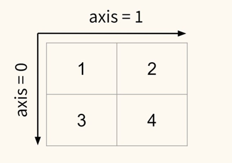

Если массив не одномерный, можно задать ось, по которой будет происходить соединение. По умолчанию axis=0.

```python
np.concatenate((a,b), axis=0)
```

```
array([[1., 2.],
       [3., 4.],
       [5., 6.],
       [7., 8.]])
```

```python
np.concatenate((a,b), axis=1)
```

```
array([[1., 2., 5., 6.],
       [3., 4., 7., 8.]])
```

```python
c = np.array([[10, 20, 30, 40], [50, 60, 70, 80]])
c
```

```
array([[10, 20, 30, 40],
       [50, 60, 70, 80]])
```

Считаем сумму по столбцам (двигаемся вдоль оси 0)

```python
np.sum(c, axis=0)
```

```
array([ 60,  80, 100, 120])
```

Считаем сумму по строкам (двигаемся вдоль оси 1)

```python
np.sum(c, axis=1)
```

```
array([100, 260])
```

## Работа по ссылке

Работа по ссылке как и в python:

```python
a = np.array([1, 2, 3])
b = a
c =  a.copy()

# меняем 0й элемент
a[0] = 0

print(f'Измененный массив а {a}')
print(f'Измененный массив b {b}  <-- изменился по ссылке т.к. поменяли 0й элемент а')
print(f'Измененный массив c {c}  <-- создали копию в памяти')
```

```
Измененный массив а [0 2 3]
Измененный массив b [0 2 3]  <-- изменился по ссылке т.к. поменяли 0й элемент а
Измененный массив c [1 2 3]  <-- создали копию в памяти
```